# Prosper Loan Data

## by Louis Dods

#### Original Questions

- How is our data distributed
- What are significant variables in deciphering borrower APR.
- What is a significant variable in inducing investors to invest in certain loans

## Preliminary Wrangling

> I am working with loan data provided in the project lesson.

```python
# import all packages and set plots to be embedded inline
import numpy as np
import pandas as pd
import matplotlib.pyplot as plt
import seaborn as sb

%matplotlib inline
```

```python
base_color = sb.color_palette()[0]
```

> Load in your dataset and describe its properties through the questions below. Try and motivate your exploration goals through this section.

### Access

```python
df = pd.read_csv('LoanData.csv')
```

```python
df.shape
```

```
(113937, 81)
```

```python
df.head()
```

|  | ListingKey | ListingNumber | ListingCreationDate | CreditGrade | Term | LoanStatus | ClosedDate | BorrowerAPR | BorrowerRate | LenderYield | ... | LP_ServiceFees | LP_CollectionFees | LP_GrossPrincipalLoss | LP_NetPrincipalLoss | LP_NonPrincipalRecoverypayments | PercentFunded | Recommendations | InvestmentFromFriendsCount | InvestmentFromFriendsAmount | Investors |
| --- | --- | --- | --- | --- | --- | --- | --- | --- | --- | --- | --- | --- | --- | --- | --- | --- | --- | --- | --- | --- | --- |
| 0 | 1021339766868145413AB3B | 193129 | 2007-08-26 19:09:29.263000000 | C | 36 | Completed | 2009-08-14 00:00:00 | 0.16516 | 0.1580 | 0.1380 | ... | -133.18 | 0.0 | 0.0 | 0.0 | 0.0 | 1.0 | 0 | 0 | 0.0 | 258 |
| 1 | 10273602499503308B223C1 | 1209647 | 2014-02-27 08:28:07.900000000 | NaN | 36 | Current | NaN | 0.12016 | 0.0920 | 0.0820 | ... | 0.00 | 0.0 | 0.0 | 0.0 | 0.0 | 1.0 | 0 | 0 | 0.0 | 1 |
| 2 | 0EE9337825851032864889A | 81716 | 2007-01-05 15:00:47.090000000 | HR | 36 | Completed | 2009-12-17 00:00:00 | 0.28269 | 0.2750 | 0.2400 | ... | -24.20 | 0.0 | 0.0 | 0.0 | 0.0 | 1.0 | 0 | 0 | 0.0 | 41 |
| 3 | 0EF5356002482715299901A | 658116 | 2012-10-22 11:02:35.010000000 | NaN | 36 | Current | NaN | 0.12528 | 0.0974 | 0.0874 | ... | -108.01 | 0.0 | 0.0 | 0.0 | 0.0 | 1.0 | 0 | 0 | 0.0 | 158 |
| 4 | 0F023589499656230C5E3E2 | 909464 | 2013-09-14 18:38:39.097000000 | NaN | 36 | Current | NaN | 0.24614 | 0.2085 | 0.1985 | ... | -60.27 | 0.0 | 0.0 | 0.0 | 0.0 | 1.0 | 0 | 0 | 0.0 | 20 |

5 rows × 81 columns

```python
df.describe()
```

|  | ListingNumber | Term | BorrowerAPR | BorrowerRate | LenderYield | EstimatedEffectiveYield | EstimatedLoss | EstimatedReturn | ProsperRating (numeric) | ProsperScore | ... | LP_ServiceFees | LP_CollectionFees | LP_GrossPrincipalLoss | LP_NetPrincipalLoss | LP_NonPrincipalRecoverypayments | PercentFunded | Recommendations | InvestmentFromFriendsCount | InvestmentFromFriendsAmount | Investors |
| --- | --- | --- | --- | --- | --- | --- | --- | --- | --- | --- | --- | --- | --- | --- | --- | --- | --- | --- | --- | --- | --- |
| count | 1.139370e+05 | 113937.000000 | 113912.000000 | 113937.000000 | 113937.000000 | 84853.000000 | 84853.000000 | 84853.000000 | 84853.000000 | 84853.000000 | ... | 113937.000000 | 113937.000000 | 113937.000000 | 113937.000000 | 113937.000000 | 113937.000000 | 113937.000000 | 113937.000000 | 113937.000000 | 113937.000000 |
| mean | 6.278857e+05 | 40.830248 | 0.218828 | 0.192764 | 0.182701 | 0.168661 | 0.080306 | 0.096068 | 4.072243 | 5.950067 | ... | -54.725641 | -14.242698 | 700.446342 | 681.420499 | 25.142686 | 0.998584 | 0.048027 | 0.023460 | 16.550751 | 80.475228 |
| std | 3.280762e+05 | 10.436212 | 0.080364 | 0.074818 | 0.074516 | 0.068467 | 0.046764 | 0.030403 | 1.673227 | 2.376501 | ... | 60.675425 | 109.232758 | 2388.513831 | 2357.167068 | 275.657937 | 0.017919 | 0.332353 | 0.232412 | 294.545422 | 103.239020 |
| min | 4.000000e+00 | 12.000000 | 0.006530 | 0.000000 | -0.010000 | -0.182700 | 0.004900 | -0.182700 | 1.000000 | 1.000000 | ... | -664.870000 | -9274.750000 | -94.200000 | -954.550000 | 0.000000 | 0.700000 | 0.000000 | 0.000000 | 0.000000 | 1.000000 |
| 25% | 4.009190e+05 | 36.000000 | 0.156290 | 0.134000 | 0.124200 | 0.115670 | 0.042400 | 0.074080 | 3.000000 | 4.000000 | ... | -73.180000 | 0.000000 | 0.000000 | 0.000000 | 0.000000 | 1.000000 | 0.000000 | 0.000000 | 0.000000 | 2.000000 |
| 50% | 6.005540e+05 | 36.000000 | 0.209760 | 0.184000 | 0.173000 | 0.161500 | 0.072400 | 0.091700 | 4.000000 | 6.000000 | ... | -34.440000 | 0.000000 | 0.000000 | 0.000000 | 0.000000 | 1.000000 | 0.000000 | 0.000000 | 0.000000 | 44.000000 |
| 75% | 8.926340e+05 | 36.000000 | 0.283810 | 0.250000 | 0.240000 | 0.224300 | 0.112000 | 0.116600 | 5.000000 | 8.000000 | ... | -13.920000 | 0.000000 | 0.000000 | 0.000000 | 0.000000 | 1.000000 | 0.000000 | 0.000000 | 0.000000 | 115.000000 |
| max | 1.255725e+06 | 60.000000 | 0.512290 | 0.497500 | 0.492500 | 0.319900 | 0.366000 | 0.283700 | 7.000000 | 11.000000 | ... | 32.060000 | 0.000000 | 25000.000000 | 25000.000000 | 21117.900000 | 1.012500 | 39.000000 | 33.000000 | 25000.000000 | 1189.000000 |

8 rows × 61 columns

```python
df.IncomeRange.value_counts()
```

```
$25,000-49,999    32192
$50,000-74,999    31050
$100,000+         17337
$75,000-99,999    16916
Not displayed      7741
$1-24,999          7274
Not employed        806
$0                  621
Name: IncomeRange, dtype: int64
```

### Describe Missing Data

> Above I can observe that this catorgorical feature has an issue with missing data and also a repeat column, 0 dollars and not employed being the same thing. Therefore I am going to replace not-emplooyed insances with 0 dollars and replace not displayed with np.nan.

##### Code

```python
df.IncomeRange.replace('Not displayed', np.nan, inplace=True)
df.IncomeRange.replace('Not employed', '$0', inplace=True)
```

```python
df.IncomeRange.value_counts()
```

```
$25,000-49,999    32192
$50,000-74,999    31050
$100,000+         17337
$75,000-99,999    16916
$1-24,999          7274
$0                 1427
Name: IncomeRange, dtype: int64
```

##### Test

```python
df.IncomeRange.isnull().sum()
```

```
7741
```

> That has now been completed. I will now do this for the employment category as we have the saem issue there.

### Describe missing data 2

```python
df.EmploymentStatus.value_counts()
```

```
Employed         67322
Full-time        26355
Self-employed     6134
Not available     5347
Other             3806
Part-time         1088
Not employed       835
Retired            795
Name: EmploymentStatus, dtype: int64
```

##### Code

```python
df.EmploymentStatus.replace('Full-time', 'Employed', inplace=True)
df.EmploymentStatus.replace('Self-employed', 'Employed', inplace=True)
df.EmploymentStatus.replace('Not available', np.nan, inplace=True)
```

```python
df.EmploymentStatus.value_counts()
```

```
Employed        99811
Other            3806
Part-time        1088
Not employed      835
Retired           795
Name: EmploymentStatus, dtype: int64
```

##### Test

```python
df.EmploymentStatus.isnull().sum()
```

```
7602
```

> Describe missing data 2 has now been resolved.

> I am now going to create an ordinal variable dictionary that may come in handy during exploration.

```python
ordinal_var_dict = {'IncomeRange': ['$0', '$1-24,999', '$25,000-49,999', '$50,000-74,999',
                                   '$75,000-99,999', '$100,000+'],
                   'CreditGrade' : ['NR', 'HR', 'E', 'D', 'C', 'B', 'A', 'AA']}
```

```python
df.to_csv('mdf')
```

### What is the structure of your dataset?

> (113937, 81)

Value counts:

- C 5649
- D 5153
- B 4389
- AA 3509
- HR 3508
- A 3315
- E 3289
- NC 141
- (with 84984 missing vlaues)
- ListingCreationDate (0 null) and ClosedDate (58848) (wrtong dytpes however)

### What is/are the main feature(s) of interest in your dataset?

> I am most interested in what features are best for predicting borrowersAPR. What is tricky about this is that a lot of our statistics are set by the borrowerAPR. For example Lender Yield is obviosuly staiscially dependent on borrower APR and we do not need statiscal evidence to understand this. Therefore I will be looking for variabls that are separate from this. My guess is that APR is set off propser rating and prosper rating is there to take into account catorgorical variables such as employment and income range etc.

### What features in the dataset do you think will help support your investigation into your feature(s) of interest?

> I expect that Prospers rating system will have the strongest correlation with the APR but it is then important to observe what predicts the Prospers rating to manfacture a strong understanding of this dataset.

### Function definitions

> Below are functions that I have written and will use throughout my exploration and analysis.

```python
def bivaraite_countplot_order(df, x, y, order):
    sb.barplot(data=df, x=x, y=y, color=base_color, order=order)
    plt.xlabel(x)
    plt.ylabel(y);

def bivaraite_countplot(df, x, y):
    sb.barplot(data=df, x=x, y=y, color=base_color)
    plt.xlabel(x)
    plt.ylabel(y);

def bivaraite_countplot_order_xrot(x, y, order):
    plt.xticks(rotation=35)
    sb.barplot(data=df, x=x, y=y, color=base_color, order=order)
    plt.xlabel(x)
    plt.ylabel(y);

def scatter_bivariate(variable_y, variable_x):
    sb.regplot(data = df, x = variable_x, y = variable_y);
    plt.xlabel(variable_x)
    plt.ylabel(variable_y);

def univariate_countplot(variable):
    counts = df[variable].value_counts()
    order = counts.index
    return sb.countplot(data = df, y = variable, order = order, color=base_color);
```

## Univariate Exploration

> In this section I will investigate distributions of individual variables. If I see unusual points or outliers I will take a deeper look to clean things up and prepare myself to look at relationships between variables.

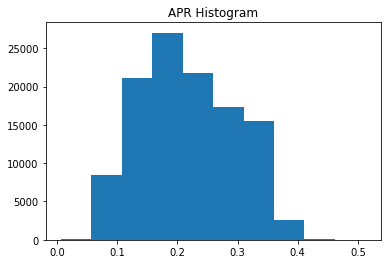

```python
plt.hist(data = df, x = 'BorrowerAPR')
plt.title('APR Histogram');
```

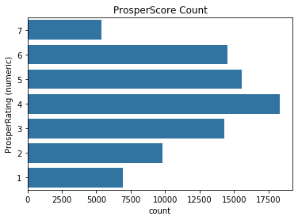

```python
counts = df['ProsperScore'].value_counts()
order = counts.index
sb.countplot(data = df, y = 'ProsperRating (numeric)',
             order = [7,6,5,4,3,2,1], color=base_color).set_title('ProsperScore Count');
```

- The Prosper Rating assigned at the time the listing was created: 0 - N/A, 1 - HR, 2 - E, 3 - D, 4 - C, 5 - B, 6 - A, 7 - AA. Applicable for loans originated after July 2009.

> Here we can observe the distribution of prosper ratings and see that 4 is the most common and the genmral trend being that the close to the middle the more common with a slight skew making higher ratings more common.

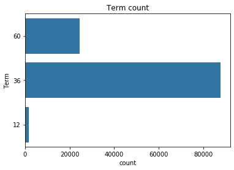

```python
counts = df['Term'].value_counts()
order = counts.index
sb.countplot(data = df, y = 'Term', order = [60,36,12], color=base_color).set_title('Term count');
```

> Here we can see that 3 term catorgories exist, 36, 60, 12. 36 being by far the most prevalent with barely any 12 term loands present.

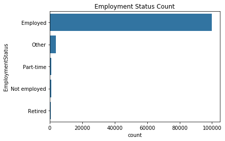

```python
counts = df['EmploymentStatus'].value_counts()
order = counts.index
sb.countplot(data = df, y = 'EmploymentStatus', order = order, color=base_color).set_title('Employment Status Count');
```

> Because our data is by and large only involved with employed people looking for a staiscally relationship between these catorgories would be very hard.

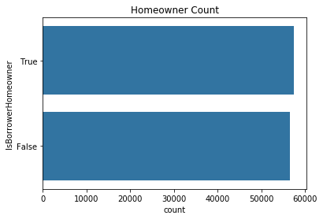

```python
counts = df['IsBorrowerHomeowner'].value_counts()
order = counts.index
sb.countplot(data = df, y = 'IsBorrowerHomeowner', order = order, color=base_color).set_title('Homeowner Count');
```

> Looks like our group are approximately half homewowners and half not. This is a nice distribution within which it will be effective for us to explore.

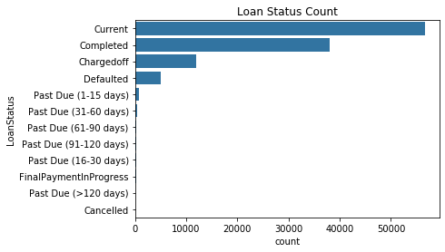

```python
counts = df['LoanStatus'].value_counts()
order = counts.index
sb.countplot(data = df, y = 'LoanStatus', order = order, color=base_color).set_title('Loan Status Count');
```

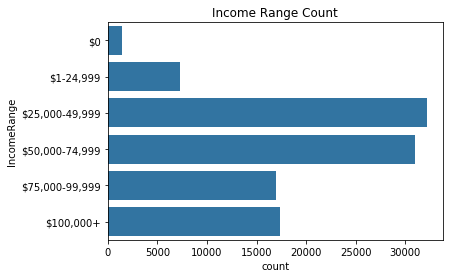

```python
counts = df['IncomeRange'].value_counts()
sb.countplot(data = df, y = 'IncomeRange', order=['$0', '$1-24,999', '$25,000-49,999', '$50,000-74,999',
                                   '$75,000-99,999', '$100,000+'],color=base_color).set_title('Income Range Count');
```

> Most loans are being taken out by the middle group. It would be interesting to observe the relationship between this catogory and the prospect (numeric) score.

### Talk about some of the relationships you observed in this part of the investigation. How did the feature(s) of interest vary with other features in the dataset?

- Even amount of homeowners and non-homeowners
- With more people of the middle income groups taking out loans it appears interesting to see whether on average this catorgorical variable has an effect on Prospects rating.

## Multivariate Exploration Part 1

> I think here it is worth producing a heatmap so that we may observe correlation between all our numeric variables with ease. This may gratn us insight into what we want to look at later in our exploartion and analysis.

```python
df.columns.to_series().groupby(df.dtypes).groups;
```

```python
bool_list = list(df.select_dtypes(include=['bool']).columns)
o_list = list(df.select_dtypes(include=['O']).columns)
int_list = list(df.select_dtypes(include=['int64']).columns)
float_list = list(df.select_dtypes(include=['float64']).columns)
numeric_vars = int_list + float_list
categoric_vars = bool_list + o_list
```

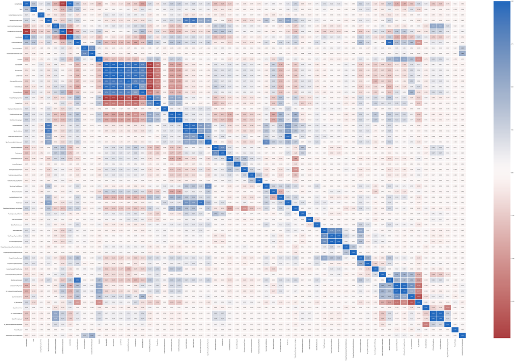

```python
# correlation plot
plt.figure(figsize = [96, 60])
sb.heatmap(df[numeric_vars].corr(), annot = True, linewidths=3, fmt = '.3f',
           cmap = 'vlag_r', center = 0)
plt.show()
```

## Bivariate Exploration

> In this section, investigate relationships between pairs of variables in your data. Make sure the variables that you cover here have been introduced in some fashion in the previous section (univariate exploration).

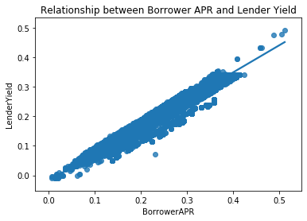

```python
sb.regplot(data = df, x = 'BorrowerAPR', y = 'LenderYield').set_title('Relationship between Borrower APR and Lender Yield');
```

> This is a visualisation of what we already know and what was stated at the begning of the notebook. BorrowerAPR is strongly correlated to LenderYield and any discrepiency will be due to fees felt on either side for processing the loan.

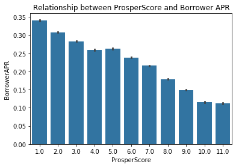

```python
sb.barplot(data=df, x='ProsperScore', y='BorrowerAPR', color=base_color).set_title('Relationship between ProsperScore and Borrower APR');
```

> Here it appears that there is a strong correlation between ProsperScore and BorrowerAPR. I am taking this and the preceding scatter graph as confirmation of the theory that Prosper Score sets the APR set for the borrower and hence my next steps will look to anlayse what effects this Prosper rating that the APR is dependent on.

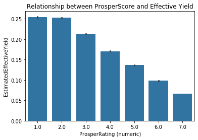

```python
sb.barplot(data=df, x='ProsperRating (numeric)',
           y='EstimatedEffectiveYield',
           color=base_color).set_title('Relationship between ProsperScore and Effective Yield');
```

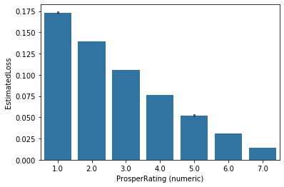

```python
bivaraite_countplot(df, 'ProsperRating (numeric)', 'EstimatedLoss')
```

> Of course we could not obtain these two variables without first having set APR and completed the proceding calculations, therefore it is clear that EstimatedYield and Loss are not useful in deciphering what variables are most significant in terms of setting borrowe APR. Therefore this strong corelation observed in the two countplots above are not significant in my analysis in this project.

#### Relationship between ProsperScore and income

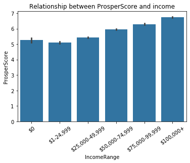

```python
plt.xticks(rotation=35)
sb.barplot(data=df, x='IncomeRange', y='ProsperScore', color=base_color,
           order=['$0', '$1-24,999', '$25,000-49,999',
                  '$50,000-74,999', '$75,000-99,999',
                  '$100,000+']).set_title('Relationship between ProsperScore and income');
```

#### Relationship between ProsperScore and Debt

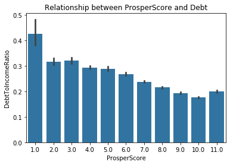

```python
sb.barplot(data=df, x='ProsperScore', y='DebtToIncomeRatio', color=base_color).set_title('Relationship between ProsperScore and Debt');
```

> Here we can observe a clear relationship between DebtToIncomeRatio and ProsperScore that suggests that the higher this ration the lower the ProsperScore and as we have already conclusded that ProsperScore determines APR to a large extent then we can conclude here that borrower debt is a significant varibale in decding borrower APR.

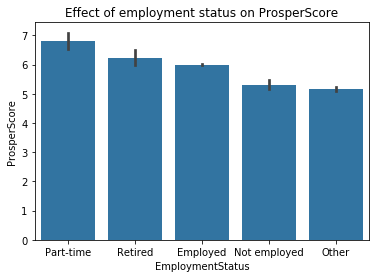

```python
sb.barplot(data=df, x='EmploymentStatus', y='ProsperScore', color=base_color, order=['Part-time',
                                                                         'Retired',
                                                                         'Employed',
                                                                         'Not employed',
                                                                         'Other',]).set_title('Effect of employment status on ProsperScore');
```

> Here we can see that part-timers actually receive the best ProsperScore on average. This is ratehr strange as I expected employed people to receive ths. However when we observe the distribution of data (In [20]) then we can see that the vast majority of the the distribution are people who are employed and with so little loans from people in any catorgories other thanemployed I believe that no wiorthwhile conclusions can be drawn on this front.

#### Investors Sentiment

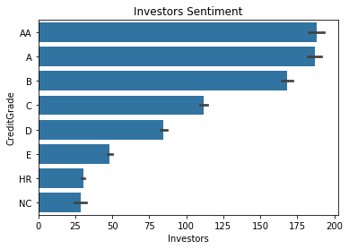

```python
sb.barplot(data=df, x='Investors', y='CreditGrade',
           order=['AA', 'A', 'B', 'C', 'D', 'E', 'HR', 'NC'], color=base_color).set_title('Investors Sentiment')
plt.ylabel('CreditGrade');
```

> Here we can see that investors strongly favour AA and A loans to invest in. The higher the rating the more investment. This answers one of my project questions quite clearly.

### Summary of bivaraite exploration

> Here I have exlpored the relationships between ProsperScore and: debt, income and employment status after concluding that prosperscore is what defines borrowers APR and also that estimated loss and yield are factors which cannot effect this score because their calculation procedes teh setting of borrower APR.

> Clearly debt has a negative correlation with ProsperScore and income has a postive one. When it came to employment status exploration I conlcuded that thedistriubution of the dataset on this front was not suitable for us to draw any conlusions from.

## Multivariate Exploration Part 2

> Create plots of three or more variables to investigate your data even further. Make sure that your investigations are justified, and follow from your work in the previous sections.

```python
df.EmploymentStatus.value_counts()
```

```
Employed        99811
Other            3806
Part-time        1088
Not employed      835
Retired           795
Name: EmploymentStatus, dtype: int64
```

```python
df.EmploymentStatus.replace('Not employed', np.nan, inplace=True)
```

```python
df.EmploymentStatus.value_counts()
```

```
Employed     99811
Other         3806
Part-time     1088
Retired        795
Name: EmploymentStatus, dtype: int64
```

#### Controlling for homeowner status

```python
df_homeowner = df[df['IsBorrowerHomeowner']== True]
df_nothomeowner = df[df['IsBorrowerHomeowner']== False]
```

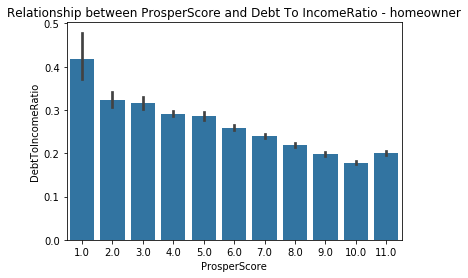

```python
sb.barplot(data=df_homeowner, x='ProsperScore', y='DebtToIncomeRatio', color=base_color).set_title('Relationship between ProsperScore and Debt To IncomeRatio - homeowner')
```

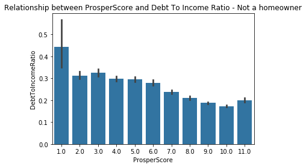

```python
sb.barplot(data=df_nothomeowner, x='ProsperScore', y='DebtToIncomeRatio', color=base_color).set_title('Relationship between ProsperScore and Debt To Income Ratio - Not a homeowner')
```

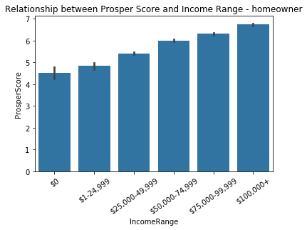

```python
plt.xticks(rotation=35)
sb.barplot(data=df_homeowner, x='IncomeRange', y='ProsperScore', color=base_color, order=['$0', '$1-24,999',
                                                                                             '$25,000-49,999',
                                                                                             '$50,000-74,999',
                                                                                             '$75,000-99,999',
                                                                                             '$100,000+']).set_title('Relationship between Prosper Score and Income Range - homeowner');
```

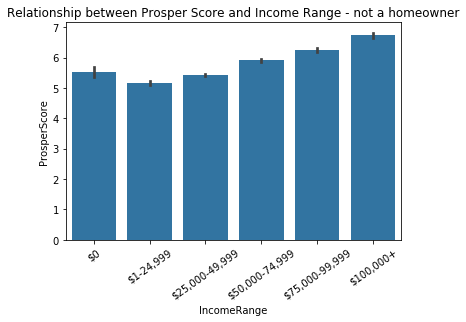

```python
plt.xticks(rotation=35)
sb.barplot(data=df_nothomeowner, x='IncomeRange', y='ProsperScore', color=base_color, order=['$0', '$1-24,999',
                                                                                             '$25,000-49,999',
                                                                                             '$50,000-74,999',
                                                                                             '$75,000-99,999',
                                                                                             '$100,000+']).set_title('Relationship between Prosper Score and Income Range - not a homeowner');
```

### Talk about some of the relationships you observed in this part of the investigation. Were there features that strengthened each other in terms of looking at your feature(s) of interest?

> After controlling for homeownership I found that the relationship betwen ProsperScore with debt and income respectively is the same. Hence we can conclude from this that the there is strong negative relationship betwen debt and ProsperScore and a strong postive one with income range, therefore because of what we have conlcuded concerning ProsperScore and borrower APR we can then extend the abovementioned relationships onto to APR. Stating that with higher debt to income ratios borrowers should expect higher APR rates and lower rates for higher incomes.

> At the end of your report, make sure that you export the notebook as an html file from the `File > Download as... > HTML` menu. Make sure you keep track of where the exported file goes, so you can put it in the same folder as this notebook for project submission. Also, make sure you remove all of the quote-formatted guide notes like this one before you finish your report!